# Toolbox Food Webs Analysis

Léo Ledru

2024-07-04

# Introduction

This RMarkdown document is dedicated to the analysis of food webs, particularly the study of indirect effects between species within the network and the trophic cascade process.

- 0. Inference of food webs from data (abundances, biological characteristics…): Vagnon et al. 2021 (Ecosphere)
- 1. **Mandatory :** Loading food web and verifications
- 2. Foodweb analysis: direct and net effects heatmap, identification of trophic chains, calculation of trophic cascades, chain integration
- 3. Referencing indirect effects
- 4. Graphic food web visualization
- 5. Visualization of trophic cascades with inversion
- 6. Stability and dynamics of food web

### Install packages

```r
# install.packages("rmarkdown")
# install.packages("deSolve")
# install.packages("NetIndices") # to compute trophic levels and omnivory
# install.packages("sparsevar") # for spectralRadius function
# install.packages("expm") # for %^% operator
# install.packages("purrr") # is_empty function
# install.packages("rlist") # for list.reverse()
# install.packages("igraph") # to show food web as a graph
# install.packages("RColorBrewer")
# install.packages("scales")
# install.packages("ggplot2")
# install.packages("docstring") # allow to call the docstring of functions used in this RMarkdown as native R functions, by calling ?<functionName>
# install.packages("roxygen2")
# install.packages("reshape2")
# install.packages("pracma")
```

## Inference of food web from data (Vagnon et al. 2021)

See https://doi.org/10.1002/ecs2.3420, in particular AppendixS4 with the associated github repository https://github.com/chloevagnon/aNM_method.

## Loading food web and verifications

**This section must be run before any other sections below, as it involves loading the food web to be analyzed and checking its validity.**

The first necessary step is to load a food web in the form of an interaction matrix. This matrix must respect several properties:

- It must be square, since the rows and columns correspond to the species in the food web.
- All matrix elements must be numeric.
- The species in rows and columns must be arranged in the same order, so that the diagonal of the matrix corresponds to self-regulation, i.e. the direct effect of a species on itself. All other elements $a_{ij}$ of the matrix correspond to the effect of species $j$ (in column) on species $i$ (in row).
- The elements on the diagonal correspond to self-regulation: if they have been inferred, they must be $<0$; if not, they are set to $-1$, so that normalization by self-regulation to obtain the dimensionless matrix for calculating indirect effects (Zelnik et al. 2024) will not change the inferred interaction values.
- The matrix must represent a food web, so every negative value must have a positive symmetrical value (although the positive value may be different, typically lower due to a conversion coefficient.

The following code block loads a test food web, then the *CheckInit* function performs a check on the interaction matrix, which must validate the aforementioned properties or an error message will be returned.

```
## [1] "The food web is validated"
```

### Names & indices

In the remainder of this document, species in the food web are often referred to by their index in the interaction matrix (their line number). To make it easier for the user to draw parallels between indices and species names, the following code section generates a data-frame associating the index and abbreviated name for each species name.

```
##                                 Names Abbreviation Indices
## OBL_60-70                   OBL_60-70        OBL_6       1
## CRI_40-50                   CRI_40-50        CRI_4       2
## CRI_30-40                   CRI_30-40        CRI_3       3
## OBL_20-30                   OBL_20-30        OBL_2       4
## OBL_10-20                   OBL_10-20        OBL_1       5
## NEMATHELMINTHA_sp. NEMATHELMINTHA_sp.        NEMAT       6
```

## Food web analysis: direct and net effects, collectivity, connectance, omnivory, trophic cascades, food chain integration

### Heatmaps of direct and net effects

An easily informative representation of the food web is to simply display the interaction matrix as a heatmap: as a reminder, an interaction is read from column $j$ to row $i$.

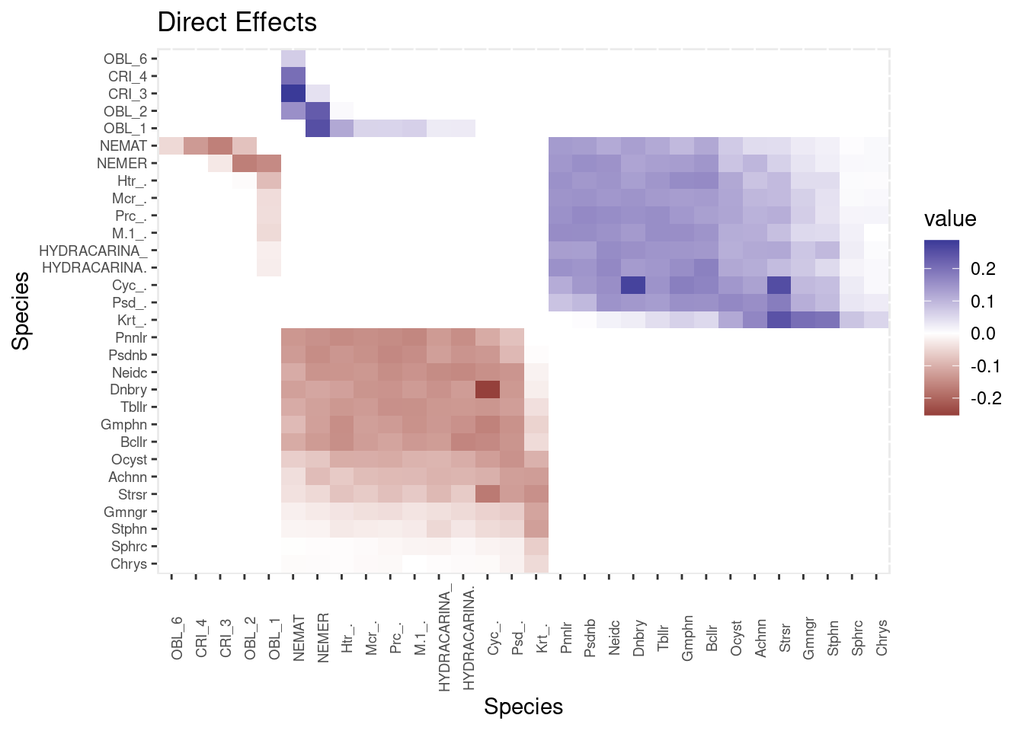

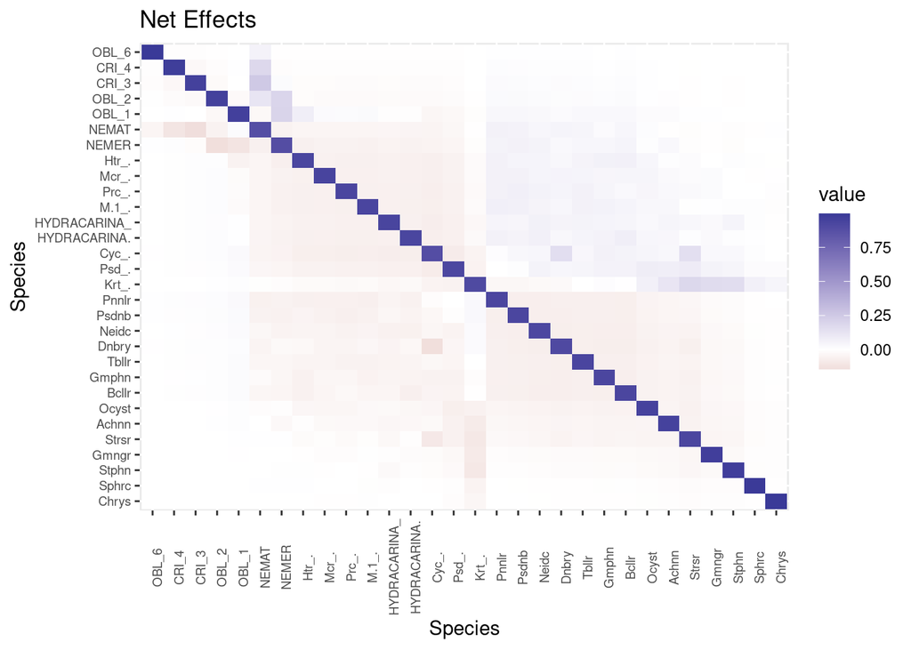

### Length of chains

A trophic chain is considered to start from a predator-free species to a prey-free species (basal species). The function below identifies all the chains in the food web meeting this criterion and measures the average chain size in the food web, as well as the standard deviation.

```
## [1] "Mean chains length =  2.82627118644068  sd chains length =  0.379681381788578"
```

### In-depth trophic cascades analysis

This section calculates several proxies on the food web and especially on each trophic chains.

However, as can be seen from the previous function on chain length, the network may contain predator apexes with different trophic levels (e.g. 3 and 4), so the user must choose from which trophic level to evaluate the food chains. If there are predator apexes at several levels, the user could execute the function once for each level. On the other hand, if he chooses a trophic level with no predator apex (predator having no predator itself) then the function will return an error message. Furthermore, in order to evaluate the trophic cascade process, the trophic level selected must be at least 3.

All the results are stored in a list of lists called *FoodWebMetrics*. This list contains :

- Collectivity (Zelnik et al. 2024)
- Connectance
- Average omnivory
- A sub-list with measures characterizing the trophic cascade process expressed by each trophic chain in the food web (Ledru et al. 2024) :
- - *Top*: Predator index
  - *Middle*: Consumer index
  - *Bottom: Resource index*
  - Value of short-term trophic cascade, i.e. the indirect effect from the *Top* to the *Bottom*
  - Value of long-term trophic cascade, i.e. the net effect from *Top* to *Bottom*
  - Long-term/short-term ratio showing whether there is a divergence between the two cascades.
  - Value of the integration of the chain in the food web, i.e. the ratio of the summed interactions between the chain and the rest of the food web with the summed interactions within the chain. This constitutes a proxy of the collectivity experienced by the trophic chain, the greater if the integration of the chain, the more strongly the chain interacts with the rest of the food web.

**NB**: Trophic chains are identified as follows; 1) calculation of the trophic level of each species, 2) identification of the maximum trophic level (must be at least 3) and the species with this level (the *Top*), 3) identification of species with a trophic level two levels below the maximum level (if type=“n2”), or basal species (if type=“basal), (the *Bottom*), 4) identification of intermediate species link the *Top* and *Bottom* (the *Middle*).

With the parameter type=“n2” the analysis considers a trophic chain as running from the top of the food web to the top-2 level, considering a classic trophic cascade as an indirect effect of order 2. Therefore, if a food web has a maximum trophic level greater than 3 trophic cascade (and so trophic chains) will not go all the way down to the basal species.

```
## $Collectivity
## [1] 1.352222
##
## $Connectance
## [1] 0.3816092
##
## $MeanOmnivory
## [1] 6.203539e-30
##
## $FoodWebMetrics
##    Top                  Middle Bottom DirectCascade    NetCascade RatioCascades
## 1    1                       6     17  0.0065257974  3.044774e-03    0.46657494
## 2    1                       6     18  0.0062287313  2.757815e-03    0.44275704
## 3    1                       6     19  0.0052197976  1.743576e-03    0.33403126
## 4    1                       6     20  0.0058976289  2.301651e-03    0.39026722
```

[output cut: 137 more lines]

## Referencing indirect effects.

Indirect effects can extend across the food web, potentially up to long order, connecting all species. This section calculates for each species with which it is connected for each order up to chosen maximum order. It also gives for each species the limit order (*OrderLim*) at which it has interacted with all others, considering the cumulative orders.

```
## $`OBL_60-70`
## $`OBL_60-70`$order1
## NEMATHELMINTHA_sp.
##                  6
##
## $`OBL_60-70`$order2
##            OBL_60-70            CRI_40-50            CRI_30-40
##                    1                    2                    3
##            OBL_20-30       Pinnulariaceae    Pseudanabaenaceae
##                    4                   17                   18
##           Neidiaceae         Dinobryaceae       Tabellariaceae
##                   19                   20                   21
##     Gomphonemataceae       Bacillariaceae          Oocystaceae
##                   22                   23                   24
##     Achnanthidiaceae       Staurosiraceae       Geminigeraceae
##                   25                   26                   27
##    Stephanodiscaceae   Sphaerocystidaceae Chrysochromulinaceae
##                   28                   29                   30
##
## $`OBL_60-70`$order3
##      NEMATHELMINTHA_sp.            NEMERTEA_sp. Heterotrissocladius_sp.
##                       6                       7                       8
##        Micropsectra_sp.         Paracladius_sp.     Micropsectra.1_sp.1
##                       9                      10                      11
##         HYDRACARINA_sp.      HYDRACARINA.1_sp.1             Cyclops_sp.
##                      12                      13                      14
##       Pseudodiamesa_sp.           Keratella_sp.
##                      15                      16
##
## $`OBL_60-70`$order4
##            OBL_60-70            CRI_40-50            CRI_30-40
##                    1                    2                    3
##            OBL_20-30            OBL_10-20       Pinnulariaceae
##                    4                    5                   17
##    Pseudanabaenaceae           Neidiaceae         Dinobryaceae
##                   18                   19                   20
##       Tabellariaceae     Gomphonemataceae       Bacillariaceae
##                   21                   22                   23
##          Oocystaceae     Achnanthidiaceae       Staurosiraceae
##                   24                   25                   26
```

[output cut: 317 more lines]

```
##            OBL_20-30            OBL_10-20       Pinnulariaceae
##                    4                    5                   17
##    Pseudanabaenaceae           Neidiaceae         Dinobryaceae
##                   18                   19                   20
##       Tabellariaceae     Gomphonemataceae       Bacillariaceae
##                   21                   22                   23
##          Oocystaceae     Achnanthidiaceae       Staurosiraceae
##                   24                   25                   26
##       Geminigeraceae    Stephanodiscaceae   Sphaerocystidaceae
##                   27                   28                   29
## Chrysochromulinaceae
##                   30
##
## $NEMATHELMINTHA_sp.$orderLim
## [1] 3
```

## Graphic food web visualization

A graphical visualization of the food web can provide an intuitive understanding of the relationships involved more easily than from the raw interaction matrix. This section provides this visualization in the form of nodes (species) connected by links (interactions).

Of course, for a food web, each link is bidirectional, meaning a positive effect of the prey on the predator in one direction and a negative effect of the predator on the prey in the other, but this subtlety is not represented and each prey-predator pair is simply connected by a link. On the other hand, the thickness of the link indicates the strength of the interaction.

The user can select a species of interest by its index in the interaction matrix via the *IdxFocusSpecies* parameter. In this case, the species’ node will appear in green, the species’ direct links will appear in red, as well as connected nodes, and in blue will be second-order links and connected species. This makes it easy to get an idea of the role the species of interest can play in the food web through its interactions with other species. To find out with whom the species of interest interacts for larger orders of indirect effects refer to the previous section.

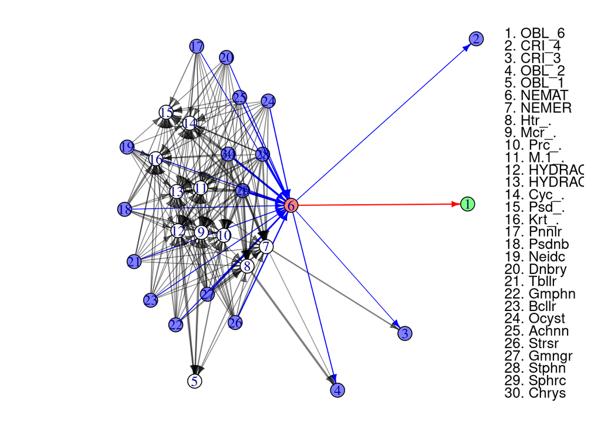

## Inverted chain

The trophic cascade concept considers that the indirect effect of a predator in a trophic chain on the species two trophic levels lower in the trophic chain is positive, via its direct negative effect on the intermediate level. More generally, starting from a predator, its effect should be negative on lower trophic levels separated by an odd distance, and positive on levels separated by an even distance. For example, from a predator of trophic level 3 to a resource of trophic level 1, the distance being 2 links, the effect should be positive.

However, (Ledru et al. 2024) shows that in complex ecological networks it is no longer possible to consider trophic chains independently of each other. Indeed, multiple and potentially large indirect effects can disrupt the strictly top-down trophic cascade, so that the long-term trophic cascade, measured by the net effects between species, can be inverted in relation to the classic (short-term) trophic cascade.

The following code section identifies trophic chains likely to express an inverted trophic cascade and highlights them.

To see the precise value of each trophic cascade, refer to the *FoodWebMetrics* list calculated in the Food web analysis section.

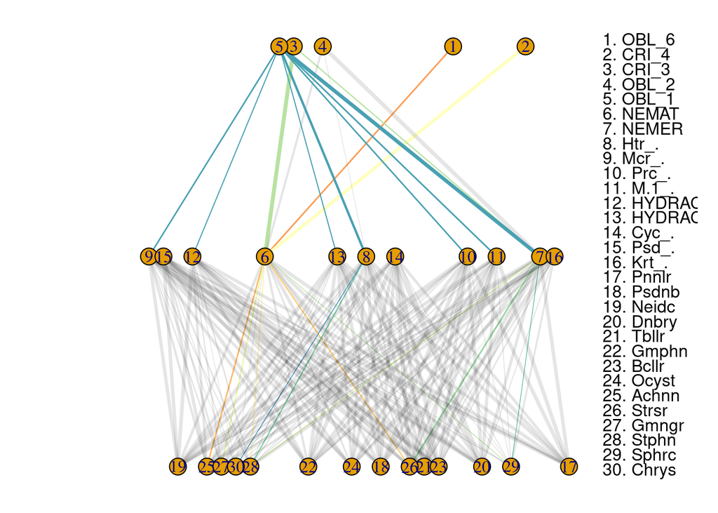

## Stability and dynamics of food web

### Visualizing the network in eigenvalue space

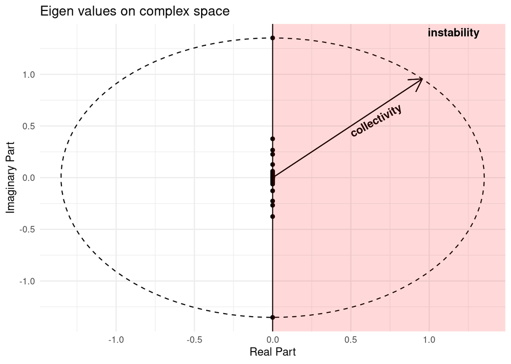

```
## [1] "The maximum real part of eigen value is : 1.32930721446255e-17"
```

### A proxy of stability

One estimate of stability, inspired by Neutel, Heesterbeek, and De Ruiter (2002) and Neutel et al. (2007), is to measure the minimum self-regulation (i.e. the value on the diagonal of the interaction matrix) required for the largest Real value of the matrix eigenvalues to be negative (Sauve et al. 2016). **This is only a proxy for stability** based on the interaction matrix, since the true *Jacobian* matrix of the network would consist in applying the species densities to the interaction matrix. This method therefore amounts to measuring the minimum self-regulation for the network to be stable in the particular configuration where *all species have the same equilibrium density.*

**This proxy can be used to compare networks or to assess the impact of adding or removing a species from a network on its stability.**

```
## The minimum self-regulation (with the Threshold used) that must be applied to the
##  network for it to be stable is :  6.103516e-05
```

### Another proxy of stability: the recovery time

This proxy was introduced by Pimm and Lawton (1977), a larger recovery time indicates a lower stability. However, be careful of some limitations highlighted by Arnoldi et al. (2018).

```
## [1] "RecoveryTime is  1"
```

### Food web dynamics

Food web dynamics can be simulated in a fairly general way using the Generalized Lotka-Volterra (GLV) model. The dynamics of each species depend on its intrinsic growth rate (positive or negative, depending on whether it is autotrophic or heterotrophic) and the sum of interactions with other species (the interaction matrix). The GLV therefore has just one parameter, the growth rate, which we break down into two: the GrowthRate of basal species and the DeathRate of non-basal species.

#### Simulation to equilibrium

The code section below tests whether, given the input parameters (growth rate and death rate), the system actually reaches a stable equilibrium without any extinction. If there are one or more extinctions, the species are removed and the simulation starts again, until a stable system is reached. In the case of a simulated food web, this results in a stable configuration. In the case of an empirically inferred food web, which is suggested to be stable because it has been observed, the user can find the appropriate parameters to obtain a stable system without any extinction or species removal. These parameters can then be used in the next section.

[1] 1 2 integer(0)

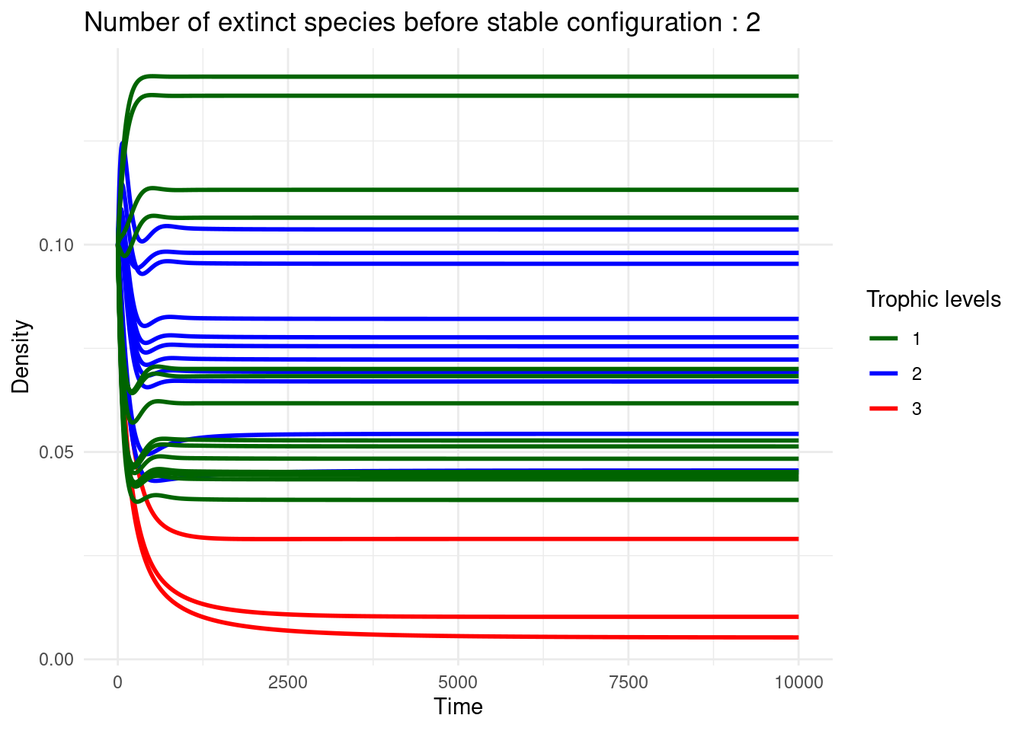

#### Food web disturbance

Once we have the configuration of the system at equilibrium (the species that persist and their density at equilibrium), we may want to see how the food web responds to the disturbance of one or more species. This allows us, for example, to directly visualize the dynamics of a cascade inversion potentially identified in the dedicated section. This section of the code consists in choosing one or more species to be disturbed, i.e. whose growth/mortality rate will be modified, either positively or negatively. System dynamics in response to this disturbance are then simulated and plotted.

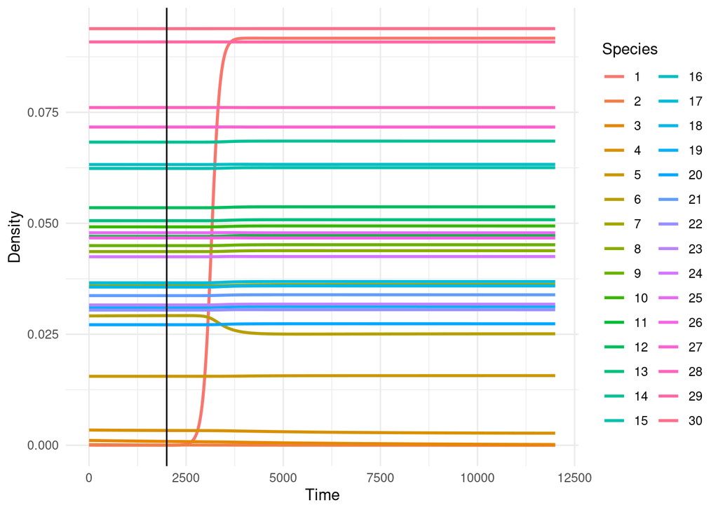

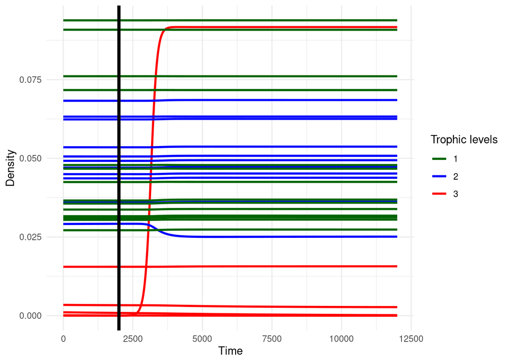

Arnoldi, J.-F., A. Bideault, M. Loreau, and B. Haegeman. 2018. “How Ecosystems Recover from Pulse Perturbations: A Theory of Short- to Long-Term Responses.” *Journal of Theoretical Biology* 436 (January): 79–92. https://doi.org/10.1016/j.jtbi.2017.10.003.

Ledru, Léo, Arnaud Sentis, Jean-François Arnoldi, and Victor Frossard. 2024. “Trophic Cascades in Complex Ecological Networks.”

Neutel, Anje-Margriet, Johan AP Heesterbeek, and Peter C De Ruiter. 2002. “Stability in Real Food Webs: Weak Links in Long Loops.” *Science* 296 (5570): 1120–23.

Neutel, Anje-Margriet, Johan AP Heesterbeek, Johan Van de Koppel, Guido Hoenderboom, An Vos, Coen Kaldeway, Frank Berendse, and Peter C De Ruiter. 2007. “Reconciling Complexity with Stability in Naturally Assembling Food Webs.” *Nature* 449 (7162): 599–602.

Pimm, S. L., and J. H. Lawton. 1977. “Number of Trophic Levels in Ecological Communities.” *Nature* 268 (5618): 329–31. https://doi.org/10.1038/268329a0.

Sauve, Alix MC, Elisa Thébault, Michael JO Pocock, and Colin Fontaine. 2016. “How Plants Connect Pollination and Herbivory Networks and Their Contribution to Community Stability.” *Ecology* 97 (4): 908–17.

Zelnik, Yuval R., Nuria Galiana, Matthieu Barbier, Michel Loreau, Eric Galbraith, and Jean-François Arnoldi. 2024. “How Collectively Integrated Are Ecological Communities?” *Ecology Letters* 27 (1): e14358. https://doi.org/10.1111/ele.14358.